```python
HTML('''<script>
code_show=true;
function code_toggle() {
 if (code_show){
 $('div.input').hide();
 } else {
 $('div.input').show();
 }
 code_show = !code_show
}
$( document ).ready(code_toggle);
</script>
 <a href="javascript:code_toggle()"></a>.''')
```

.

# Data Quality Report

This is the data quality report of the dataset `NY property`. The dataset contains `30` columns, `1,048,575` rows.

## The summary table for numeric variables

```python
summary_table
```

|  | count | mean | std | min | 25% | 50% | 75% | max | populated_rate |
| --- | --- | --- | --- | --- | --- | --- | --- | --- | --- |
| RECORD | 1048575.0 | 524288.000000 | 3.026977e+05 | 1.0 | 262144.5 | 524288.0 | 786431.50 | 1.048575e+06 | 1.0000 |
| BLOCK | 1048575.0 | 4708.867421 | 3.699547e+03 | 1.0 | 1534.0 | 3944.0 | 6797.00 | 1.635000e+04 | 1.0000 |
| LOT | 1048575.0 | 370.092395 | 8.605382e+02 | 1.0 | 23.0 | 49.0 | 146.00 | 9.978000e+03 | 1.0000 |
| LTFRONT | 1048575.0 | 36.174248 | 7.373356e+01 | 0.0 | 19.0 | 25.0 | 40.00 | 9.999000e+03 | 1.0000 |
| LTDEPTH | 1048575.0 | 88.276429 | 7.547885e+01 | 0.0 | 80.0 | 100.0 | 100.00 | 9.999000e+03 | 1.0000 |
| STORIES | 996433.0 | 5.063363 | 8.431372e+00 | 1.0 | 2.0 | 2.0 | 3.00 | 1.190000e+02 | 0.9503 |
| FULLVAL | 1048575.0 | 880487.657847 | 1.170293e+07 | 0.0 | 303000.0 | 446000.0 | 619000.00 | 6.150000e+09 | 1.0000 |
| AVLAND | 1048575.0 | 85995.027083 | 4.100755e+06 | 0.0 | 9160.0 | 13646.0 | 19706.00 | 2.668500e+09 | 1.0000 |
| AVTOT | 1048575.0 | 230758.183174 | 6.951206e+06 | 0.0 | 18385.0 | 25339.0 | 46095.00 | 4.668309e+09 | 1.0000 |
| EXLAND | 1048575.0 | 36811.788682 | 4.024330e+06 | 0.0 | 0.0 | 1620.0 | 1620.00 | 2.668500e+09 | 1.0000 |
| EXTOT | 1048575.0 | 92543.814625 | 6.578281e+06 | 0.0 | 0.0 | 1620.0 | 2090.00 | 4.668309e+09 | 1.0000 |
| EXCD1 | 622642.0 | 1604.500100 | 1.388132e+03 | 1010.0 | 1017.0 | 1017.0 | 1017.00 | 7.170000e+03 | 0.5938 |
| ZIP | 1022219.0 | 10935.315946 | 5.265759e+02 | 10001.0 | 10453.0 | 11215.0 | 11364.00 | 3.380300e+04 | 0.9749 |
| BLDFRONT | 1048575.0 | 23.018722 | 3.578847e+01 | 0.0 | 15.0 | 20.0 | 24.00 | 7.575000e+03 | 1.0000 |
| BLDDEPTH | 1048575.0 | 40.074211 | 4.303640e+01 | 0.0 | 26.0 | 39.0 | 51.00 | 9.393000e+03 | 1.0000 |
| AVLAND2 | 280966.0 | 246365.484475 | 6.199390e+06 | 3.0 | 5705.0 | 20059.0 | 62338.75 | 2.371005e+09 | 0.2680 |
| AVTOT2 | 280972.0 | 716078.713584 | 1.169017e+07 | 3.0 | 34013.5 | 80010.0 | 240792.00 | 4.501180e+09 | 0.2680 |
| EXLAND2 | 86675.0 | 351802.210545 | 1.085248e+07 | 1.0 | 2090.0 | 3053.0 | 31419.00 | 2.371005e+09 | 0.0827 |
| EXTOT2 | 129933.0 | 658114.779009 | 1.612981e+07 | 7.0 | 2889.0 | 37116.0 | 106629.00 | 4.501180e+09 | 0.1239 |
| EXCD2 | 90941.0 | 1371.659098 | 1.105490e+03 | 1011.0 | 1017.0 | 1017.0 | 1017.00 | 7.160000e+03 | 0.0867 |

## RECORD

index of the dataset

```python
print('first twenty records in RECORD')
pd.DataFrame(mydata['RECORD'].head(20))
```

```
first twenty records in RECORD
```

|  | RECORD |
| --- | --- |
| 0 | 1 |
| 1 | 2 |
| 2 | 3 |
| 3 | 4 |
| 4 | 5 |
| 5 | 6 |
| 6 | 7 |
| 7 | 8 |
| 8 | 9 |
| 9 | 10 |
| 10 | 11 |
| 11 | 12 |
| 12 | 13 |
| 13 | 14 |
| 14 | 15 |
| 15 | 16 |
| 16 | 17 |
| 17 | 18 |
| 18 | 19 |
| 19 | 20 |

## BBLE

Concatenation of `BORO`, `BLOCK`, `LOT` and `EASEMENT`. Length 10 numeric + 1 alphabet (or 1 space, which indicates no `EASEMENT`).

```python
print('first twenty records in BBLE')
pd.DataFrame(mydata['BBLE'].head(20))
```

```
first twenty records in BBLE
```

|  | BBLE |
| --- | --- |
| 0 | 3046020035 |
| 1 | 5046820019 |
| 2 | 3074790028 |
| 3 | 4027980132 |
| 4 | 1006950027E |
| 5 | 4031810007 |
| 6 | 4051861001 |
| 7 | 3082020064 |
| 8 | 4052570008 |
| 9 | 3070780050 |
| 10 | 4015091025 |
| 11 | 3070900035 |
| 12 | 4153230005 |
| 13 | 5003770209 |
| 14 | 4089220014 |
| 15 | 3072791881 |
| 16 | 3046840031 |
| 17 | 4019260013 |
| 18 | 3039330053 |
| 19 | 4013950034 |

## BLOCK

Blocks within `BORO`. Length 5 numeric. The valid block ranges by `BORO` are shown below.

`MANHATTAN` 00001 to 02255, `BRONX` 02260 to 05958, `BROOKLYN` 00001 to 08955, `QUEENS` 00001 to 16350, `STATEN ISLAND` 00001 to 08050

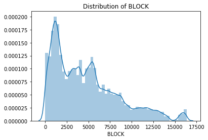

```python
sns.distplot(mydata['BLOCK'])
plt.title('Distribution of BLOCK')
plt.show()
```

## LOT

Unique number for properties within `BORO` or `BLOCK`. Length 4 numeric.

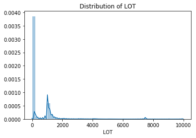

```python
sns.distplot(mydata['LOT'])
plt.title('Distribution of LOT')
plt.show()
```

## EASEMENT

Class of property rights reserved for government use.

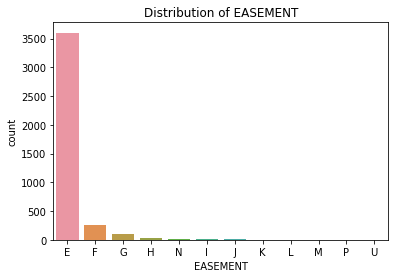

```python
sns.countplot(x='EASEMENT', data = mydata,order=mydata['EASEMENT'].value_counts().index)
plt.title('Distribution of EASEMENT')
plt.show()
```

## OWNER

Owner of the property.

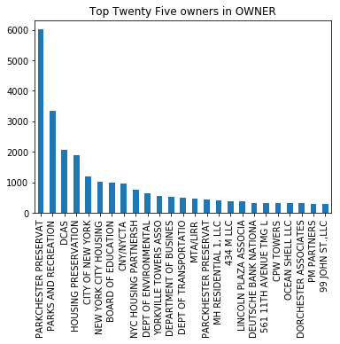

```python
mydata['OWNER'].value_counts().head(25).plot(kind='bar')
plt.title('Top Twenty Five owners in OWNER')
plt.show()
```

## BLDGCL

Building class, corresponding to `TAXCLASS`.

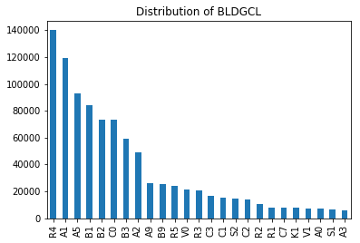

```python
mydata['BLDGCL'].value_counts().head(25).plot(kind='bar')
plt.title('Distribution of BLDGCL')
plt.show()
```

## TAXCLASS

The tax calss code.

```python
'''
VALID VALUES:

1 = 1-3 UNIT RESIDENCES

1A = 1-3 STORY CONDOMINIUMS ORIGINALLY A CONDO

1B = RESIDENTIAL VACANT LAND

1C = 1-3 UNIT CONDOMINUMS ORIGINALLY TAX CLASS 1

1D = SELECT BUNGALOW COLONIES

2 = APARTMENTS

2A = APARTMENTS WITH 4-6 UNITS

2B = APARTMENTS WITH 7-10 UNITS

2C = COOPS/CONDOS WITH 2-10 UNITS

3 = UTILITIES (EXCEPT CEILING RR)

4A = UTILITIES - CEILING RAILROADS

4 = ALL OTHERS
'''
print()
```

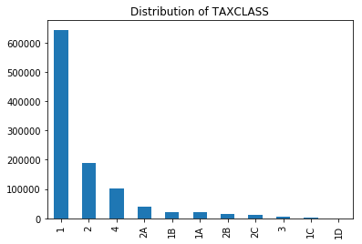

```python
mydata['TAXCLASS'].value_counts().plot(kind='bar')
plt.title('Distribution of TAXCLASS')
plt.show()
```

## LTFRONT

Lot front, the front lenth of land lot of the property

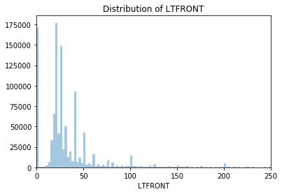

```python
xhigh = 250
plt.xlim(0,xhigh)
temp = mydata[mydata['LTFRONT'] <= xhigh]
sns.distplot(temp['LTFRONT'],bins=100, kde=False)
plt.title('Distribution of LTFRONT')
plt.show()
```

## LTDEPTH

Lot depth, the depth lenth of land lot of the property

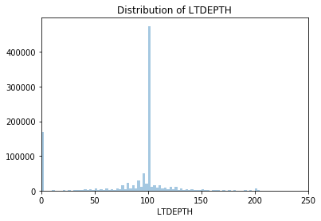

```python
xhigh = 250
plt.xlim(0,xhigh)
temp = mydata[mydata['LTDEPTH'] <= xhigh]
sns.distplot(temp['LTDEPTH'],bins=100, kde=False)
plt.title('Distribution of LTDEPTH')
plt.show()
```

## STORIES

The number of stories of the property

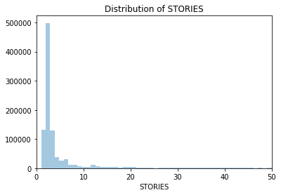

```python
xhigh = 50
temp = mydata[mydata['STORIES'] > 0]
temp.count()
plt.xlim(0,xhigh)
temp = temp[temp['STORIES'] <= xhigh]
sns.distplot(temp['STORIES'],bins=51, kde=False)
plt.title('Distribution of STORIES')
plt.show()
```

## FULLVAL

Estimated market value of the property

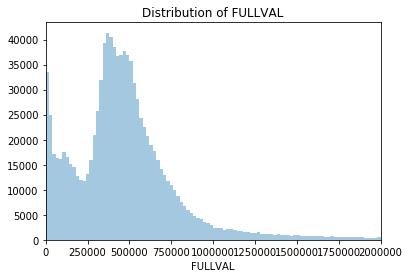

```python
xhigh = 2000000
plt.xlim(0,xhigh)
temp = mydata[mydata['FULLVAL'] <= xhigh]
sns.distplot(temp['FULLVAL'],bins=100, kde=False)
plt.title('Distribution of FULLVAL')
plt.show()
```

## AVLAND

Recorded land value of the property.

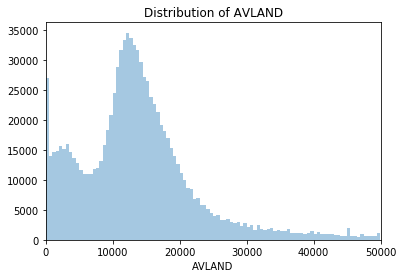

```python
xhigh = 50000
plt.xlim(0,xhigh)
temp = mydata[mydata['AVLAND'] <= xhigh]
sns.distplot(temp['AVLAND'],bins=100, kde=False)
plt.title('Distribution of AVLAND')
plt.show()
```

## AVTOT

Recorded total value of the property.

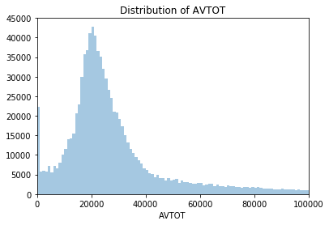

```python
xhigh = 100000
plt.xlim(0,xhigh)
temp = mydata[mydata['AVTOT'] <= xhigh]
sns.distplot(temp['AVTOT'],bins=100, kde=False)
plt.title('Distribution of AVTOT')
plt.show()
```

## EXLAND

Recorded tax exemption of the land of the property.

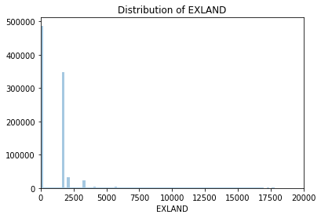

```python
xhigh = 20000
plt.xlim(0,xhigh)
temp = mydata[mydata['EXLAND'] <= xhigh]
sns.distplot(temp['EXLAND'],bins=100, kde=False)
plt.title('Distribution of EXLAND')
plt.show()
```

## EXTOT

Recorded tax exemption of the total property.

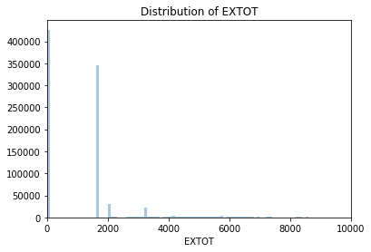

```python
xhigh = 10000
plt.xlim(0,xhigh)
temp = mydata[mydata['EXTOT'] <= xhigh]
sns.distplot(temp['EXTOT'],bins=100, kde=False)
plt.title('Distribution of EXTOT')
plt.show()
```

## EXCD1

The tax exemption code of the property, if there's exemption accessable.

```python
#mydata[mydata['EXTOT']>0].EXTOT.count()/numrecords  # the populated rate of EXTOT
```

```python
#mydata['EXCD1'].count()/numrecords  # the populated rate of EXCD1
```

```python
#len(mydata['EXCD1'].unique())
```

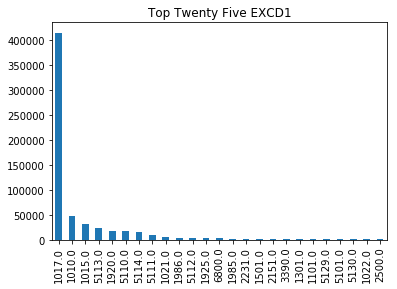

```python
mydata['EXCD1'].value_counts().head(25).plot(kind='bar')
plt.title('Top Twenty Five EXCD1')
plt.show()
```

## STADDR

Street address of the property

```python
print ('first twenty STADDR')
pd.DataFrame(mydata['STADDR'].value_counts().head(20))
```

```
first twenty STADDR
```

|  | STADDR |
| --- | --- |
| 501 SURF AVENUE | 902 |
| 330 EAST 38 STREET | 817 |
| 322 WEST 57 STREET | 720 |
| 155 WEST 68 STREET | 671 |
| 20 WEST 64 STREET | 657 |
| 1 IRVING PLACE | 650 |
| 220 RIVERSIDE BOULEVARD | 628 |
| 360 FURMAN STREET | 599 |
| 200 EAST 66 STREET | 585 |
| 30 WEST 63 STREET | 562 |
| 2 BAY CLUB DRIVE | 556 |
| 350 WEST 42 STREET | 556 |
| 200 RECTOR PLACE | 549 |
| 301 EAST 79 STREET | 538 |
| 350 WEST 50 STREET | 498 |
| 630 1 AVENUE | 488 |
| 635 WEST 42 STREET | 483 |
| 88 GREENWICH STREET | 453 |
| 150 WEST 51 STREET | 447 |
| 99 JOHN STREET | 445 |

## ZIP

Zip code of the property

```python
print('first twenty ZIP')
pd.DataFrame(mydata['ZIP'].value_counts().head(20))
```

```
first twenty ZIP
```

|  | ZIP |
| --- | --- |
| 10314.0 | 24605 |
| 11234.0 | 20001 |
| 10462.0 | 16905 |
| 10306.0 | 16576 |
| 11236.0 | 15678 |
| 11385.0 | 14921 |
| 11229.0 | 12793 |
| 11211.0 | 12710 |
| 10312.0 | 12634 |
| 11207.0 | 12293 |
| 11215.0 | 11834 |
| 11235.0 | 11312 |
| 11203.0 | 11241 |
| 11208.0 | 11139 |
| 11204.0 | 11061 |
| 10469.0 | 11030 |
| 11214.0 | 10886 |
| 11223.0 | 10741 |
| 10305.0 | 10624 |
| 11434.0 | 10505 |

## EXMPTCL

Exempt class for exempt properties.

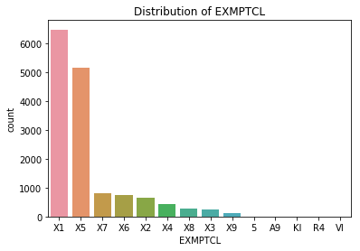

```python
sns.countplot(x='EXMPTCL', data = mydata,order=mydata['EXMPTCL'].value_counts().index)
plt.title('Distribution of EXMPTCL')
plt.show()
```

## BLDFRONT

Building front, the front lenth of building of the property.

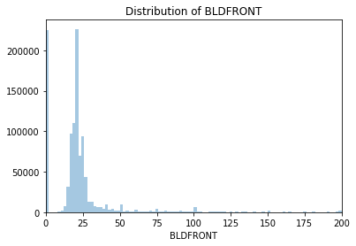

```python
xhigh = 200
plt.xlim(0,xhigh)
temp = mydata[mydata['BLDFRONT'] <= xhigh]
sns.distplot(temp['BLDFRONT'],bins=100, kde=False)
plt.title('Distribution of BLDFRONT')
plt.show()
```

## BLDDEPTH

Building depth, the depth lenth of building of the property.

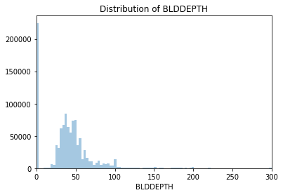

```python
xhigh = 300
plt.xlim(0,xhigh)
temp = mydata[mydata['BLDDEPTH'] <= xhigh]
sns.distplot(temp['BLDDEPTH'],bins=100, kde=False)
plt.title('Distribution of BLDDEPTH')
plt.show()
```

## AVLAND2

The second recorded land value of the property, if not `Null`.

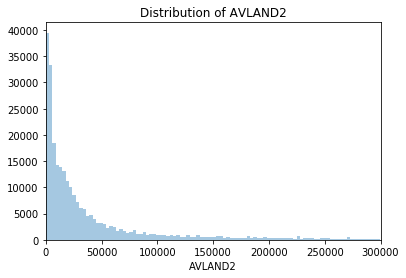

```python
xhigh = 300000
plt.xlim(0,xhigh)
temp = mydata[mydata['AVLAND2'] <= xhigh]
sns.distplot(temp['AVLAND2'],bins=100, kde=False)
plt.title('Distribution of AVLAND2')
plt.show()
```

## AVTOT2

The second recorded total value of the property, if not `Null`.

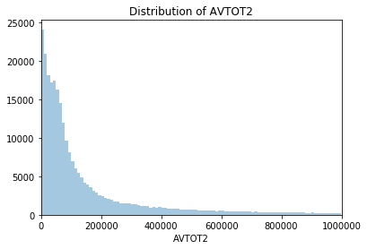

```python
xhigh = 1000000
plt.xlim(0,xhigh)
temp = mydata[mydata['AVTOT2'] <= xhigh]
sns.distplot(temp['AVTOT2'],bins=100, kde=False)
plt.title('Distribution of AVTOT2')
plt.show()
```

## EXLAND2

The second exemption of land of the property in the investigating period, if not `Null`.

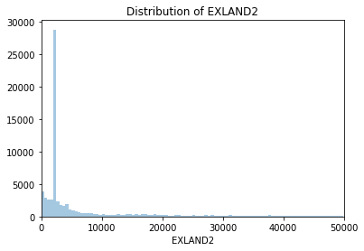

```python
xhigh = 50000
plt.xlim(0,xhigh)
temp = mydata[mydata['EXLAND2'] <= xhigh]
sns.distplot(temp['EXLAND2'],bins=100, kde=False)
plt.title('Distribution of EXLAND2')
plt.show()
```

## EXTOT2

The second exemption of the total property in the investigating period, if not `Null`.

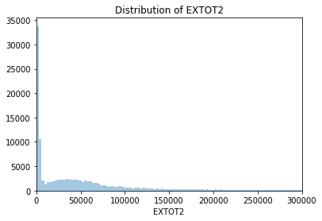

```python
xhigh = 300000
plt.xlim(0,xhigh)
temp = mydata[mydata['EXTOT2'] <= xhigh]
sns.distplot(temp['EXTOT2'],bins=100, kde=False)
plt.title('Distribution of EXTOT2')
plt.show()
```

## EXCD2

The second exemption code in the investigating period, if not `Null`.

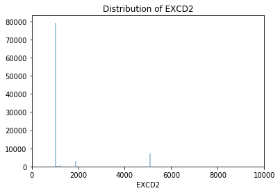

```python
xhigh = 10000
plt.xlim(0,xhigh)
temp = mydata[mydata['EXCD2'] <= xhigh]
sns.distplot(temp['EXCD2'],bins=100, kde=False)
plt.title('Distribution of EXCD2')
plt.show()
```

## PERIOD, YEAR, VALTYPE

The three variables all contain only one unique value.

```python
pd.DataFrame(d, index=['PERIOD','YEAR','VALTYPE'])
```

|  | number_of_unique_values | unique_value |
| --- | --- | --- |
| PERIOD | 1 | FINAL |
| YEAR | 1 | 2010/11 |
| VALTYPE | 1 | AC-TR |